# Nonlinear models

Loren Serfass

03/07/2015

```r
require(ggplot2)
theme_set(new = theme_minimal())
require(ISLR)
```

# Polynomials

## Polynomial linear regression

A 4-degree polynomial on `age`. The `poly` function produces orthogonal polynomials, meaning the variables produced are not correlated. This means that the significance of each variable in the model is not affected by removing any of the others. You can test each variable separately.

```r
# attach(Wage)
mod.poly4 <- lm(wage ~ poly(age,4), data=Wage)
summary(mod.poly4)
```

```
##
## Call:
## lm(formula = wage ~ poly(age, 4), data = Wage)
##
## Residuals:
##    Min     1Q Median     3Q    Max
## -98.71 -24.63  -4.99  15.22 203.69
##
## Coefficients:
##               Estimate Std. Error t value Pr(>|t|)
## (Intercept)    111.704      0.729  153.28   <2e-16 ***
## poly(age, 4)1  447.068     39.915   11.20   <2e-16 ***
## poly(age, 4)2 -478.316     39.915  -11.98   <2e-16 ***
## poly(age, 4)3  125.522     39.915    3.14   0.0017 **
## poly(age, 4)4  -77.911     39.915   -1.95   0.0510 .
## ---
## Signif. codes:  0 '***' 0.001 '**' 0.01 '*' 0.05 '.' 0.1 ' ' 1
##
## Residual standard error: 39.9 on 2995 degrees of freedom
## Multiple R-squared:  0.0863, Adjusted R-squared:  0.085
## F-statistic: 70.7 on 4 and 2995 DF,  p-value: <2e-16
```

My plot:

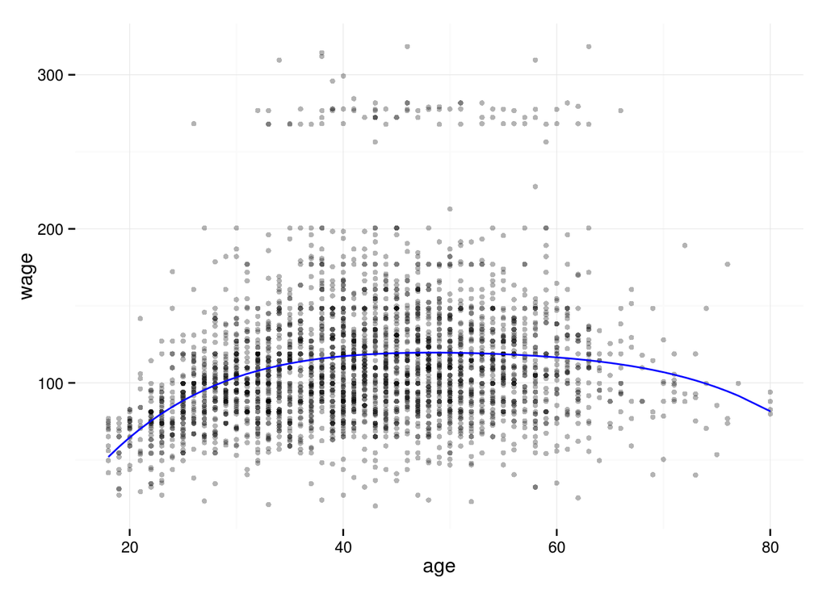

```r
p <- ggplot(Wage, aes(age, wage)) + geom_point(size=1.5, alpha=.3)
p + geom_line(aes(y=predict(mod.poly4,Wage)),color='blue')
```

Their plot (se bands with `matlines`):

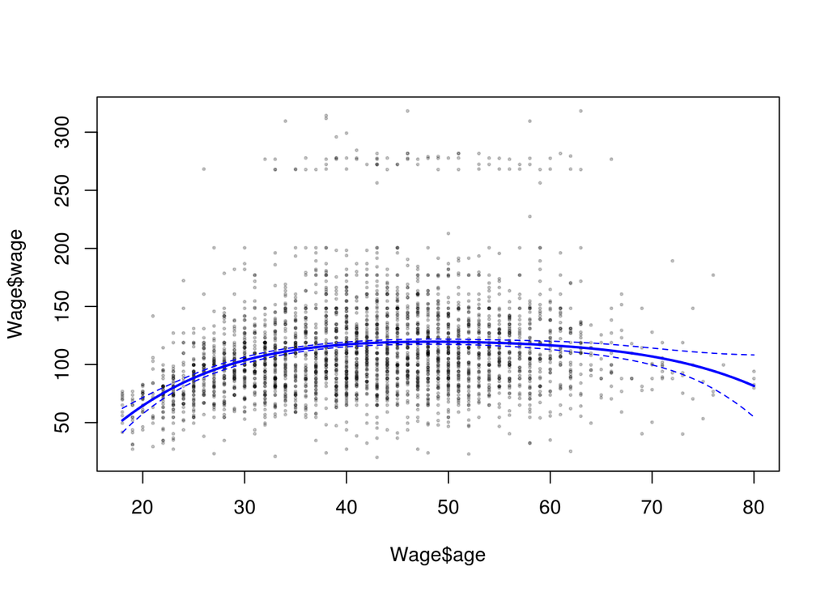

```r
agelims <- range(Wage$age)
age.seq <- seq(agelims[1], agelims[2]) # "by" defaults to 1
preds <- predict(mod.poly4, newdata=list(age=age.seq), se=T)
se.bands <- with(preds, cbind(fit - 1.96*se.fit, fit + 1.96*se.fit))
plot(Wage$age, Wage$wage, pch=19, cex=.3, col=rgb(0,0,0,.2))
lines(age.seq, preds$fit, col='blue', lwd=2)
matlines(age.seq, se.bands, col='blue', lty=2)
```

Fitting the 4th-order polynomial directly. The coefficients are different from the first model because `poly` de-correlates the polynomials. “We are using a different basis for representing the polynomials.” For this second model, removing a term will change the significance of the other terms.

```r
mod.poly4.2 <- lm(wage ~ age + I(age^2) + I(age^3) + I(age^4), data=Wage)
summary(mod.poly4.2)
```

```
##
## Call:
## lm(formula = wage ~ age + I(age^2) + I(age^3) + I(age^4), data = Wage)
##
## Residuals:
##    Min     1Q Median     3Q    Max
## -98.71 -24.63  -4.99  15.22 203.69
##
## Coefficients:
##              Estimate Std. Error t value Pr(>|t|)
## (Intercept) -1.84e+02   6.00e+01   -3.07  0.00218 **
## age          2.12e+01   5.89e+00    3.61  0.00031 ***
## I(age^2)    -5.64e-01   2.06e-01   -2.74  0.00626 **
## I(age^3)     6.81e-03   3.07e-03    2.22  0.02640 *
## I(age^4)    -3.20e-05   1.64e-05   -1.95  0.05104 .
## ---
## Signif. codes:  0 '***' 0.001 '**' 0.01 '*' 0.05 '.' 0.1 ' ' 1
##
## Residual standard error: 39.9 on 2995 degrees of freedom
## Multiple R-squared:  0.0863, Adjusted R-squared:  0.085
## F-statistic: 70.7 on 4 and 2995 DF,  p-value: <2e-16
```

But the predicted values are the same:

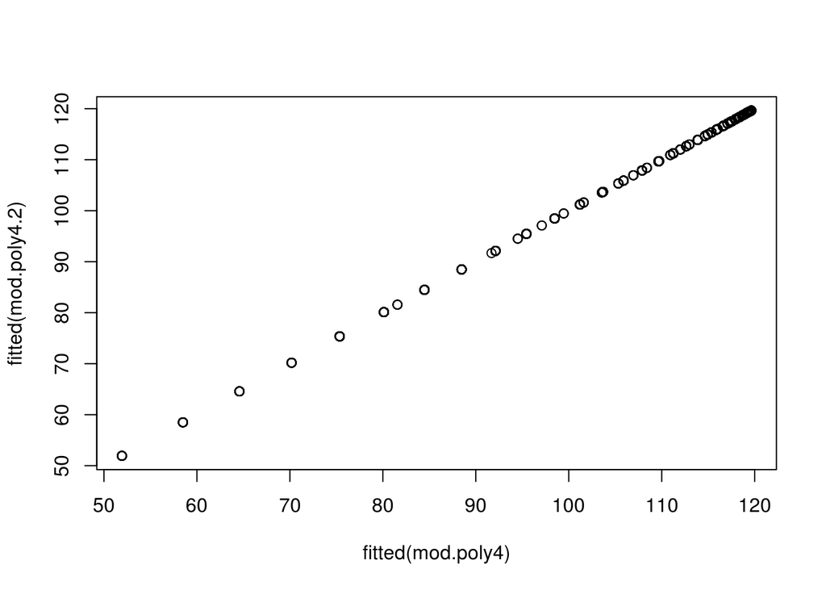

```r
plot(fitted(mod.poly4), fitted(mod.poly4.2))
```

When using `poly` on the only predictor in the model, the coefficients and p-values for each generated term are separate. But if another variable is in the model, this no longer works, and you use `anova` to compare nested models.

```r
fit.a <- lm(wage ~ education, data=Wage)
fit.b <- lm(wage ~ education + age, data=Wage)
fit.c <- lm(wage ~ education + poly(age,2), data=Wage)
fit.d <- lm(wage ~ education + poly(age,3), data=Wage)
anova(fit.a, fit.b, fit.c, fit.d)
```

```
## Analysis of Variance Table
##
## Model 1: wage ~ education
## Model 2: wage ~ education + age
## Model 3: wage ~ education + poly(age, 2)
## Model 4: wage ~ education + poly(age, 3)
##   Res.Df     RSS Df Sum of Sq      F Pr(>F)
## 1   2995 3995721
## 2   2994 3867992  1    127729 102.74 <2e-16 ***
## 3   2993 3725395  1    142597 114.70 <2e-16 ***
## 4   2992 3719809  1      5587   4.49  0.034 *
## ---
## Signif. codes:  0 '***' 0.001 '**' 0.01 '*' 0.05 '.' 0.1 ' ' 1
```

How to interpret the output above: certainly `age` and `age^2` are needed in the model with education, but not necessarily `age^3`.

## Polynomial logistic regression

We create a binary response variable from `wage`: big earners are 1, others 0.

```r
logmod.poly3 <- glm(I(wage > 250) ~ poly(age,3), data=Wage, family=binomial)
summary(logmod.poly3)
```

```
##
## Call:
## glm(formula = I(wage > 250) ~ poly(age, 3), family = binomial,
##     data = Wage)
##
## Deviance Residuals:
##    Min      1Q  Median      3Q     Max
## -0.281  -0.274  -0.249  -0.176   3.287
##
## Coefficients:
##               Estimate Std. Error z value Pr(>|z|)
## (Intercept)      -3.85       0.16  -24.10  < 2e-16 ***
## poly(age, 3)1    37.88      11.48    3.30  0.00097 ***
## poly(age, 3)2   -29.51      10.56   -2.79  0.00520 **
## poly(age, 3)3     9.80       9.00    1.09  0.27632
## ---
## Signif. codes:  0 '***' 0.001 '**' 0.01 '*' 0.05 '.' 0.1 ' ' 1
##
## (Dispersion parameter for binomial family taken to be 1)
##
##     Null deviance: 730.53  on 2999  degrees of freedom
## Residual deviance: 707.92  on 2996  degrees of freedom
## AIC: 715.9
##
## Number of Fisher Scoring iterations: 8
```

```r
# type='response' has to be the most opaque way of saying we are doing classification
preds.prob <- predict(logmod.poly3, newdata=list(age=age.seq), type='response')
```

If you want standard error bands, it seems you have to do things manually. Do the calculations “on the logit scale” (predictions not probabilities between 0 and 1), then apply logistic function $p = \frac{e^\eta}{1 + e^\eta} = \frac{1}{1 + e^{-\eta}}$

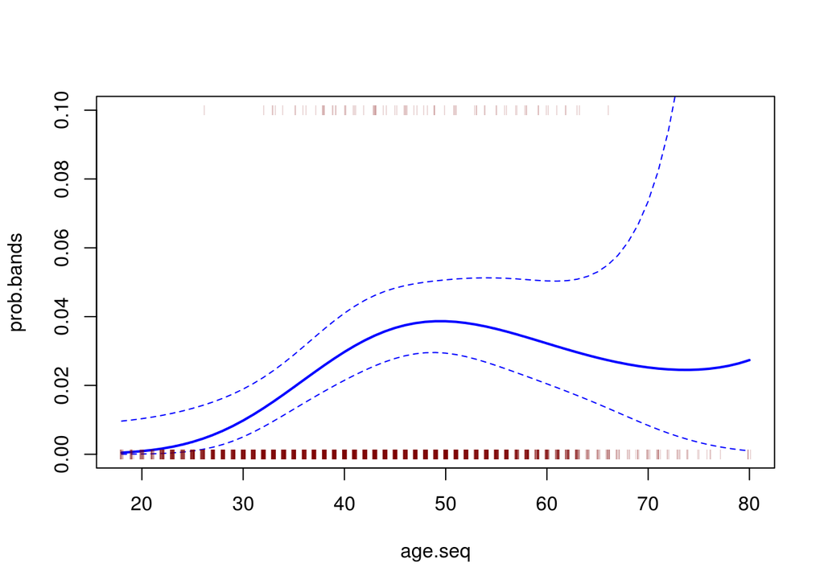

```r
preds <- predict(logmod.poly3, newdata=list(age=age.seq),se=T) # make predictions on logit scale
se.bands <- with(preds, fit + cbind(fit=0, lower=-1.96*se.fit, upper=1.96*se.fit)) # tricky
logistic <- function(x) { 1 / (1 + exp(-x)) }
prob.bands <- logistic(se.bands) # transform predictions and se bands to probability scale
matplot(age.seq, prob.bands, col='blue', type='l',
        lwd=c(2,1,1), lty=c(1,2,2), ylim=c(0,.1))
with(Wage, points(jitter(age), ifelse(wage > 250, .1, 0), pch='|', cex=.5,col=rgb(.5,0,0,.3)))
```

Let’s just check something.

```r
sum(prob.bands[,1])/length(age.seq) # "integral" over estimated probability curve
```

```
## [1] 0.02393
```

```r
sum(Wage$wage > 250) / nrow(Wage) # actual probability
```

```
## [1] 0.02633
```

# Splines

Looking at cubic splines. The `bs` function generates a “B-spline basis matrix for a polynomial spline.” **I don’t know what a B-spline basis matrix is.**

```r
require(splines)
my.knots <- c(25,40,60)
dim(bs(Wage$age, knots=my.knots)) # bs produces a  matrix with some number of columns I don't understand
```

```
## [1] 3000    6
```

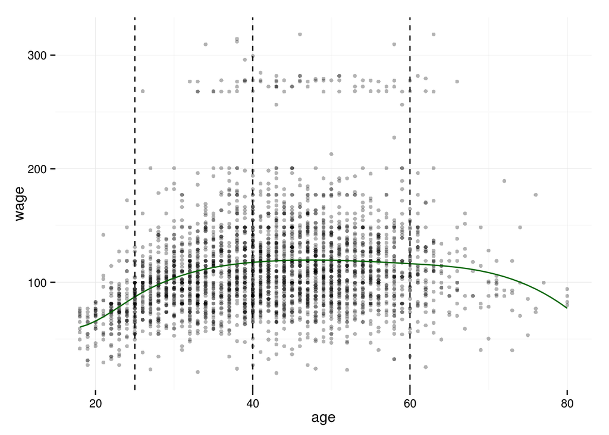

```r
# a model
mod.cubic.spline <- lm(wage ~ bs(age, knots = my.knots), data=Wage)

p2 <- p + annotate(geom='line',
                   x=age.seq, y=predict(mod.cubic.spline, newdata=list(age=age.seq)),
                   color='darkgreen') +
          geom_vline(xintercept=my.knots, linetype=2)
p2
```

Looking at smoothing splines. First, seting `df` explicitly:

```r
mod.ss <- smooth.spline(Wage$age, Wage$wage, df=16)
blah <- predict(mod.ss, newdata=list(age=age.seq))
# p + annotate(geom='line', x=blah$x, y=blah$y)
```

Now using leave-one-out cross validation to select the smoothing parameter for us automaticically:

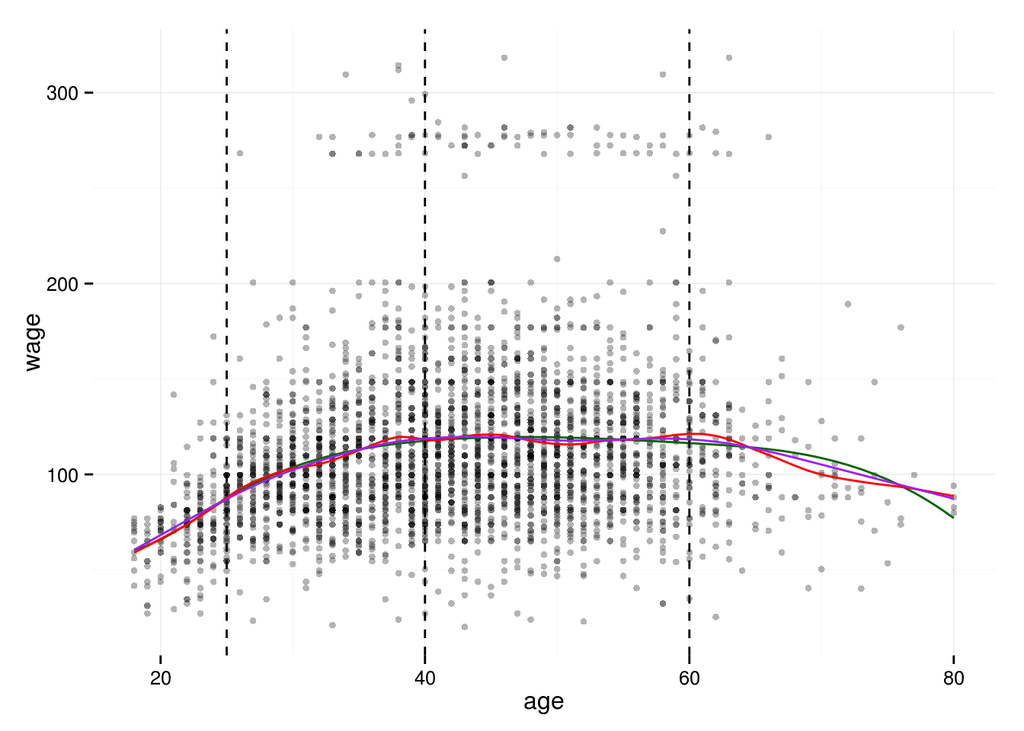

```r
mod.loo <- smooth.spline(Wage$age, Wage$wage, cv=TRUE) # I can't find LOO in documentation
p2 + annotate(geom='line', x=blah$x, y=blah$y, color='red') +
    annotate(geom='line', x=mod.loo$x, y=mod.loo$y, color='purple')
```

# Generalized Additive Models

```r
require(gam)
```

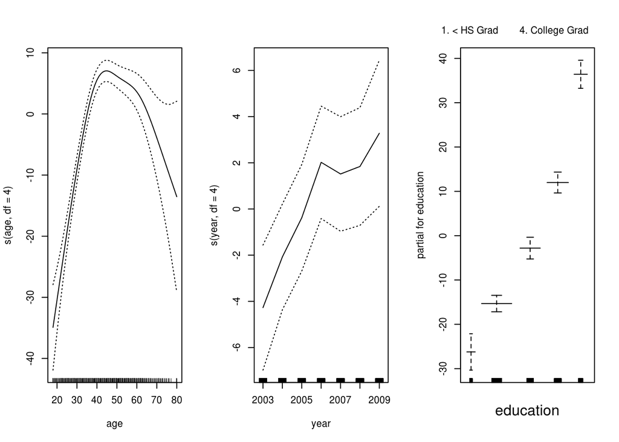

```r
gam1 <- gam(wage ~ s(age, df=4) + s(year, df=4) + education, data=Wage)
par(mfrow=c(1,3))
plot(gam1,se=T)
```

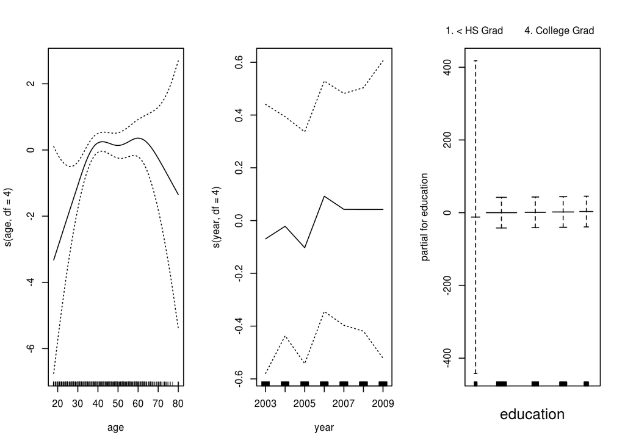

```r
gam2 <- gam(I(wage>250) ~ s(age, df=4) + s(year, df=4) + education, data=Wage, family=binomial)
plot(gam2,se=T)
```

Adding a linear term for year. The model with spline on `year` is no better than the one with linear term on `year`.

```r
gam2a <- gam(I(wage>250) ~ s(age,df=4) + year + education, data=Wage,family=binomial)
anova(gam2a, gam2, test="Chisq")
```

```
## Analysis of Deviance Table
##
## Model 1: I(wage > 250) ~ s(age, df = 4) + year + education
## Model 2: I(wage > 250) ~ s(age, df = 4) + s(year, df = 4) + education
##   Resid. Df Resid. Dev Df Deviance Pr(>Chi)
## 1      2990        604
## 2      2987        603  3    0.905     0.82
```

You can use `plot.gam` for models made with `lm`.

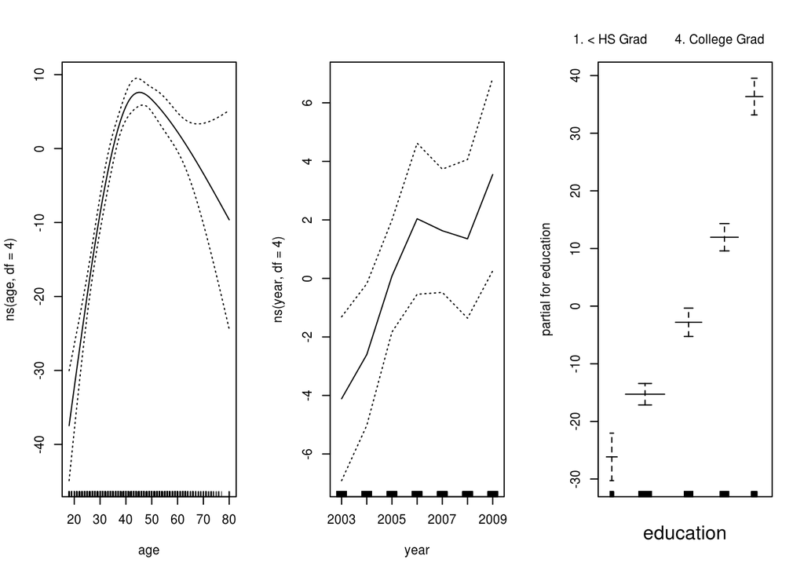

```r
par(mfrow=c(1,3))
lm1 = lm(wage ~ ns(age, df=4) + ns(year,df=4) + education, data=Wage)
plot.gam(lm1,se=T)
```

# R Quiz

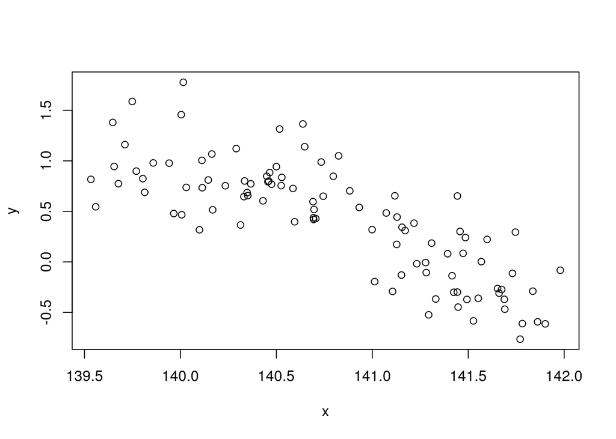

```r
load('7.R.RData')
plot(x,y)
```

```r
coef(lm(y ~ x))
```

```
## (Intercept)           x
##     95.4363     -0.6748
```

```r
coef(lm(y ~ x + I(x^2)))
```

```
## (Intercept)           x      I(x^2)
##  -5421.2467     77.7075     -0.2784
```